# 1. The SIR model: a first next-generation matrix

ReproductiveNumbers.jl vignettes

Author

Simon D. W. Frost

Published

September 18, 2026

## Overview

This vignette introduces the workflow of `ReproductiveNumbers.jl` on the simplest compartmental model, the SIR model. The construction follows Diekmann, Heesterbeek and Roberts (2010), *The construction of next-generation matrices for compartmental epidemic models* (J. R. Soc. Interface 7:873–885).

The idea is to look only at the *infected subsystem* (the compartments that can transmit or will transmit after progression), linearise it at the infection-free steady state, and split the resulting Jacobian into two parts:

- the **transmission matrix** `T`, whose entry `T[i, j]` is the rate at which an individual in infected state `j` produces *new* infections in state `i`, and
- the **transition matrix** `Σ`, containing every other change of state (progression, recovery, death), so that `-Σ⁻¹[i, j]` is the expected time an individual currently in state `j` will spend in state `i`.

The next-generation matrix with large domain is `K_L = -T Σ⁻¹`, and `R₀` is its spectral radius: the expected number of new infections produced by a typical infected individual over its whole infectious life.

## The model

```julia
using ReproductiveNumbers, ModelingToolkit, Symbolics
using ModelingToolkit: t_nounits as t, D_nounits as D

@parameters β γ N
@variables S(t) I(t) R(t)
eqs = [D(S) ~ -β * S * I / N,
    D(I) ~ β * S * I / N - γ * I,
    D(R) ~ γ * I]
sir = complete(System(eqs, t; name = :sir))
```

```
Model sir:
Equations (3):
  3 standard: see equations(sir)
Unknowns (3): see unknowns(sir)
  S(t)
  I(t)
  R(t)
Parameters (3): see parameters(sir)
  β
  N
  γ
```

## Building the next-generation matrix

The only infected compartment is `I`. Without births or deaths every state with `I = 0` is a steady state, so the infection-free steady state is not unique and we have to say which one we mean: the fully susceptible population `S = N`.

```julia
ngm = next_generation_matrix(sir, [I]; equilibrium = Dict(S => N, R => 0))
```

```
NextGenerationMatrix (symbolic) with 1 infected state(s) and 1 state(s)-at-infection
  infected:            Num[I(t)]
  states-at-infection: Num[I(t)]
  transmissions identified by: :auto
    new infections in I(t): (I(t)*S(t)*β) / N
  T =
      β
  Σ =
      -γ
  K =
      β / γ
```

The package classified the term `β S I / N` as a transmission (it involves the uninfected state `S`) and `-γ I` as a transition. The resulting matrices are `1 × 1`:

```julia
T, Σ = transmission_transition_matrices(ngm)
T, Σ
```

```
(Num[β;;], Num[-γ;;])
```

`-Σ⁻¹ = 1/γ` is the mean infectious period and `T = β` the transmission rate at the infection-free steady state, so

```julia
basic_reproduction_number(ngm)
```

```
β / γ
```

Every infected compartment here is a state-at-infection (an individual can be in it immediately after being infected):

```julia
states_at_infection(ngm)
```

```
1-element Vector{Num}:
 I(t)
```

## Numeric evaluation

Given parameter values the same object gives a number:

```julia
p = Dict(β => 0.5, γ => 0.25, N => 1000.0)
basic_reproduction_number(ngm, p)
```

```
2.0
```

or, equivalently, evaluate the whole decomposition and inspect the numeric matrices:

```julia
evaluate(ngm, p)
```

```
NextGenerationMatrix (numeric) with 1 infected state(s) and 1 state(s)-at-infection
  infected:            Num[I(t)]
  states-at-infection: Num[I(t)]
  transmissions identified by: :auto
    new infections in I(t): (I(t)*S(t)*β) / N
  T =
      0.5
  Σ =
      -0.25
  K =
      2.0
```

Parameter values can also be read from an `ODEProblem` built from the same system:

```julia
using OrdinaryDiffEqTsit5
prob = ODEProblem(sir, [S => 999.0, I => 1.0, R => 0.0, β => 0.5, γ => 0.25, N => 1000.0],
    (0.0, 60.0))
basic_reproduction_number(ngm, prob)
```

```
2.0
```

## The threshold property

`R₀ > 1` exactly when the infection-free steady state is unstable, so an epidemic can take off. We can confirm this by simulation:

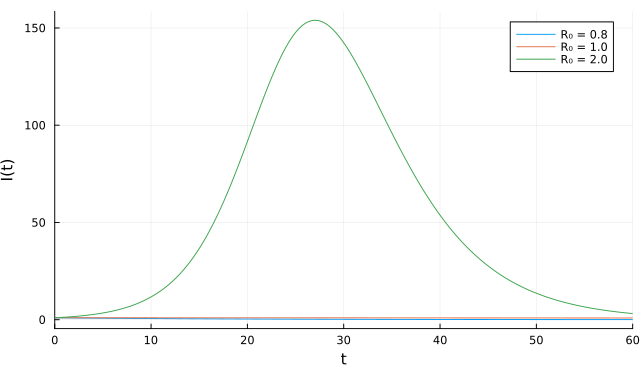

```julia
using Plots
plt = plot(xlabel = "time", ylabel = "I(t)", legend = :topright)
for βval in (0.2, 0.25, 0.5)
    prob_β = remake(prob; p = [β => βval])
    sol = solve(prob_β, Tsit5())
    plot!(plt, sol; idxs = I, label = "R₀ = $(basic_reproduction_number(ngm, prob_β))")
end
plt
```

## A reproduction number at any state

The `equilibrium` keyword accepts any state. Leaving `S` symbolic gives the reproduction number when a fraction `S/N` of the population is susceptible, i.e. the effective reproduction number `R = R₀ S / N`:

```julia
ngm_S = next_generation_matrix(sir, [I]; equilibrium = Dict(R => 0))
basic_reproduction_number(ngm_S)
```

```
(S(t)*β) / (N*γ)
```